# MDAG workshop: Part 4a BEFORE the MDAG workshop

Author

J Nienkemper-Swanepoel

# Who should read this document?

If you have an existing GitHub account, you do **NOT** have to read this document.

# Introduction and disclosure

This document is a summary of the following sources:

- [**Happy Git and GitHub for the useR**](https://happygitwithr.com/) by Jenny Bryan and [contributors](https://happygitwithr.com/contrib).
- [Software Carpentry: Version Control with Git](https://swcarpentry.github.io/git-novice/)

## Git and GitHub

- **Git** is a system for version control which is used for the management of repositories / folders. This is used locally and you can think of it as a sophisticated and **next level** form of *track changes* in Microsoft Word.
- **GitHub** is the graphical user interface which is an online hosting service for your **Git** projects. This complements **Git** and promotes open-source resources, sharing and ultimately collaboration.

You have the option of making repositories *public* or *private* on **GitHub**. Think of *private* repositories of a back-up of your local repositories which will enable a history of any changes that you have made in your project (i.e version control).

Further reading: Chapter 1 of [**Happy Git and GitHub for the useR**](https://happygitwithr.com/) and [pre-print](https://peerj.com/preprints/3159v2/).

## Getting started with GitHub

Create a free [**GitHub**](https://github.com/) account and [Sign up](https://github.com/signup?ref_cta=Sign+up&ref_loc=header+logged+out&ref_page=%2F&source=header-home).

- **Step 1**: Sign up

[figure not shown]

- **Step 2**: verify your email address

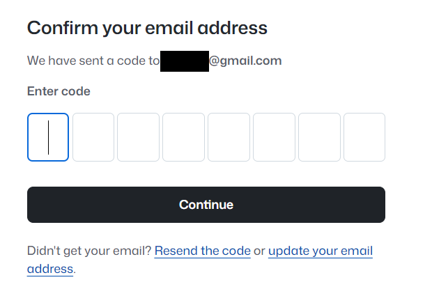

  [Multi-factor authentication](https://docs.github.com/en/authentication/securing-your-account-with-two-factor-authentication-2fa/configuring-two-factor-authentication) might be required. This is a new protocol within GitHub.
- **Step 3**: sign in

[figure not shown]

- **Step 4**: Your profile

[figure not shown]

- **Step 5**: Accessing your profile and repositories

[figure not shown]

## Next steps

- You are now ready to attend Part 4 of the MDAG workshop.
- If you want to explore the content before the workshop, you can start with the `Part4b` document.
- An optional additional document is also available for **GitHub** and **Git** integration.